# PROJEKT PRACOWNIA FIZYCZNA

```python
from resources import *
```

Struktura materii może być modelowana za pomocą $N$ elementowego zbioru punktów w przestrzeni trójwymiarowej.

W przypadku gazów punkty reprezentują obecne położenia atomów (albo jonów lub molekuł) natomiast dla kryształów są to punkty równowagi wokół, których atomy (albo jony lub molekuły) wykonują drgania.

Modele gazów zakładają brak oddziaływań międzyatomowych co sprawia, że ułożenie atomów względem siebie w przestrzeni jest przypadkowe, za to między atomami w krysztale występują wiązania co narzuca pewne uporządkowanie.

By opisać model struktury tego typu dla materii w stanie gazowym należy określić położenia wszystkich atomów, a do odtworzenia modelowej struktury kryształu wystarczy komórka elementarna wraz z wektorami translacji.

Przykładowo dla $N$ elementowej, krystalicznej sieci regularnej wystarczy położenie równowagi jednego atomu oraz $N-1$ przesunięć wraz z duplikacją o wektor:

$$\boldsymbol{T} = h\boldsymbol{a} + k\boldsymbol{b} + l\boldsymbol{c} \qquad h,k,l \in \mathbb{Z}$$

```python
plot1.display()
```

[output not shown]

Gdy dowolny podzbiór sieci krystalicznej zostanie przesunięty o wektor $\boldsymbol{T}$, wybrane węzły pokryją się z pozostałą częścią kryształu.

Jest to występująca w krysztale, symetria translacyjna.

```python
plot2.display()
```

[output not shown]

Cechą ciała krystalicznego jest uporządkowanie bliskiego i dalekiego zasięgu, natomiast w przypadku gazu położenia cząstek są zupełnie nieskorelowane.

W przypadku kryształu, każdy węzeł sieci posiada identyczne otoczenie.

Dla każdego węzła sieci w szczególnej odległości, znajduje się dana ilość sąsiadujących węzłów.

```python
plot3.display()
```

[output not shown]

W przeciwieństwie do kryształu, otoczenia atomów gazu są różne. Zarówno odległości między najbliższymi sąsiadami jak i wzajemna orientacja położeń nie wykazują korelacji. Podczas ewolucji czasowej modelowego układu w stanie gazowym (w pewnych warunkach termodynamicznych) zauważone byłyby różnice w tych matematycznych własnościach dla poszczególnych atomów, podczas gdy atomy modelowego kryształu drgały by wokół położeń równowagi.

```python
plot4.display()
```

[output not shown]

Wyżej wspomniana liczba najbliższych sąsiadów w krysztale nazywana bywa liczbą koordynacyjną.

Pojedynczą liczbę koordynacyjną można uogólnić na sekwencję liczb określających liczbę sąsiadów w kolejnych warstwach otaczających atom.

Ten sposób opisywania struktury będący zależnością liczby sąsiadów od odległości od punktu odniesienia nazywany jest radialną funkcją rozkładu (radial distribution function).

W przypadku modelu idealnego kryształu radialna funkcja rozkładu jest dyskretną sekwencją warstw koordynacyjnch.

Przykład przedstawia zależność liczby koordynacyjnej ($z$) od promienia strefy warstwy koordynacyjnej dla regularnej sieci ściennie centrowanej.

W odległości $r = 0.5 \sqrt{2}$ znajduje się $z(r) = 12$, a dla $r = 1 $ znajduje się $z(r) = 6$ sąsiadów.

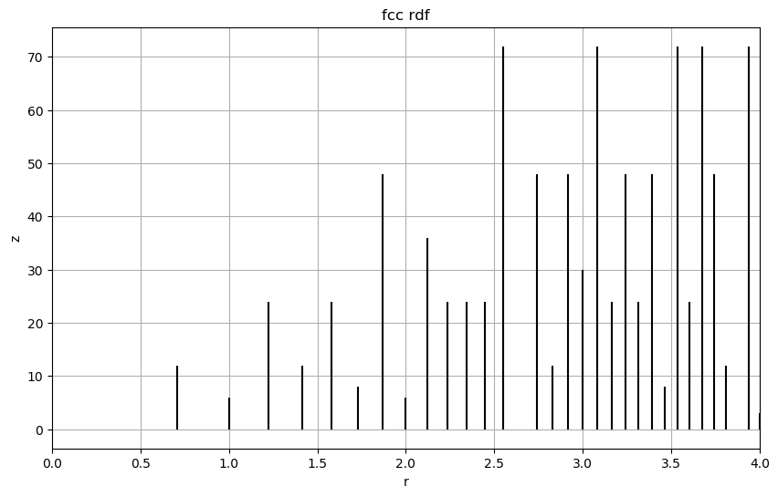

```python
fig1
```

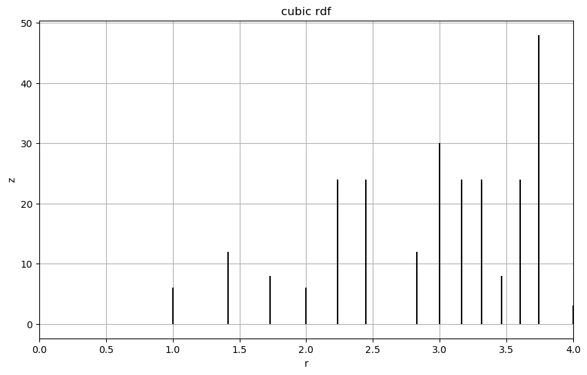

```python
fig2
```

Biorąc pod uwagę powyższe informacje oraz porównując radialne funkcje rozkładu dla obu opisywanych wyżej sieci krystalicznych można zauważyć, że sieć regularna jest podsiecią sieci regularnej ściennie centrowanej.

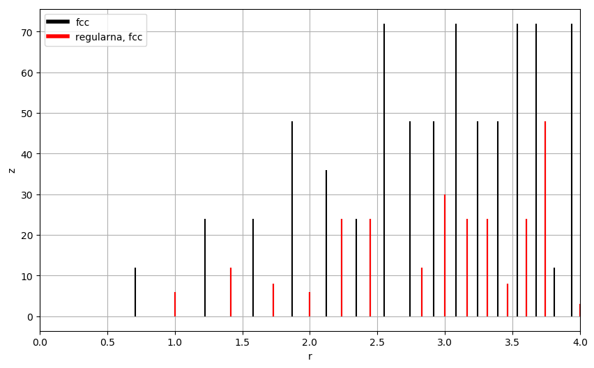

```python
fig3
```

```python
plot5.display()
```

[output not shown]

```python
plot6.display()
```

[output not shown]

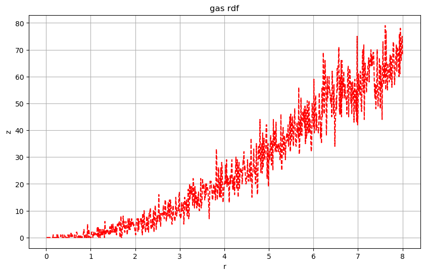

```python
fig4
```

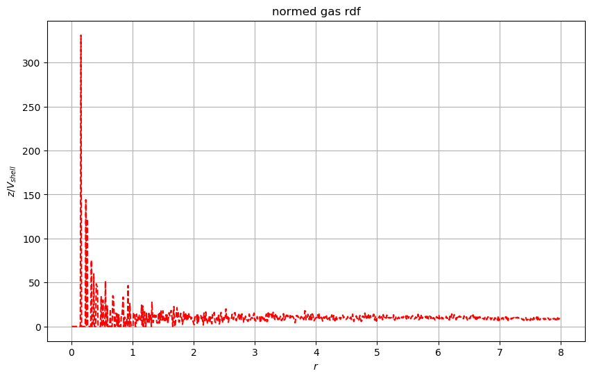

```python
fig5
```